# Praca domowa 2

Jakub Gronkiewicz

## Dane

Dane wykorzystane w Pracy domowej 2 dotyczą wyników egzaminów z 3 umiejętności: czytania, pisania i operacji matematycznych. Dodatkowo dostępne są podstawowe informacje o studentach i ich rodzicach. Opis wszystkich kolumn znajduje się również w pliku `README.md`.

| Zmienna | Opis |
| --- | --- |
| **gender** | płeć |
| **race.ethnicity** | pochodzenie etniczne |
| **parental.level.of.education** | wykształcenie rodziców |
| **lunch** | jaki obiad jedli uczniowie w dniu egzaminu |
| **test.preparation.course** | czy uczeń odbył kurs przygotowujący |
| **math.score** | wynik egzaminu z matematyki |
| **reading.score** | wynik egzaminu z czytania |
| **writing.score** | wynik egzaminu z pisania |

## Zadanie 1

Jak wyglądają rozkłady wyników uczniów z trzech przedmiotów (matematyka, czytanie, pisanie)?

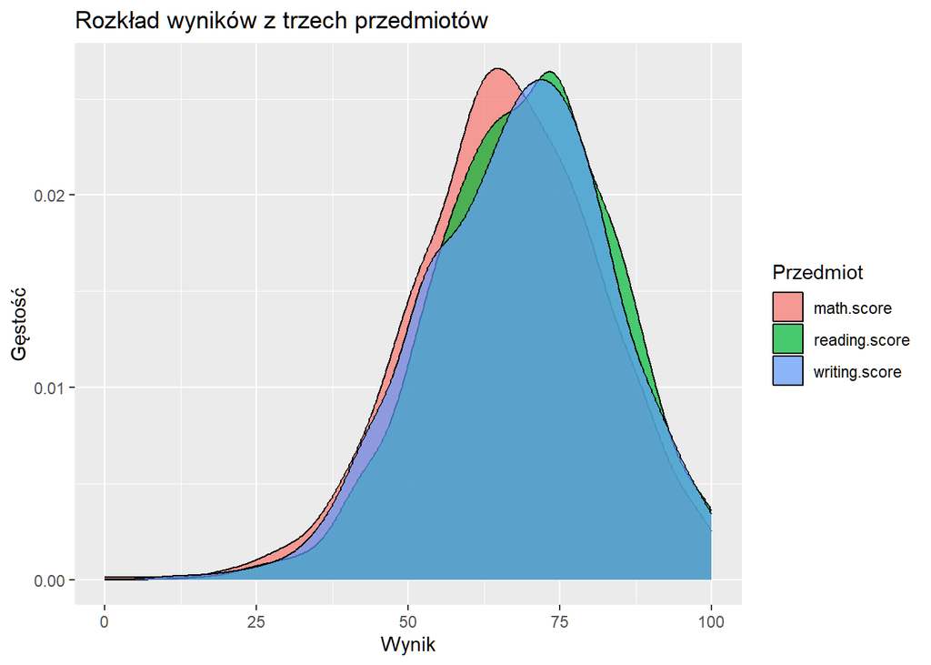

```r
df_long <- df %>%
  pivot_longer(cols = c(math.score, reading.score, writing.score),
               names_to = "subject",
               values_to = "score")

ggplot(df_long, aes(x = score, fill = subject)) +
  geom_density(alpha = 0.7) +
  labs(title = "Rozkład wyników z trzech przedmiotów",
       x = "Wynik",
       y = "Gęstość",
       fill = "Przedmiot")
```

**Komentarz:** Wszystkie trzy rozkłady wyników są w przybliżeniu rozkładami normalnymi (kształt dzwonu) i są do siebie podobne. Rozkłady wyników z czytania i pisania są niemal identyczne, z medianą w okolicach 65-70 punktów. Rozkład wyników z matematyki jest nieznacznie przesunięty w lewo, co sugeruje, że średnie wyniki z tego przedmiotu są nieco niższe niż z pozostałych dwóch.

## Zadanie 2

Czy istnieje zauważalna różnica w wynikach między uczniami i uczennicami?

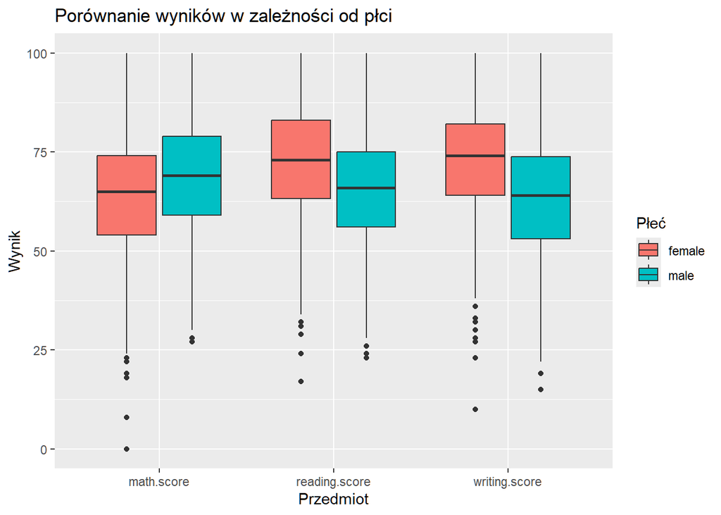

```r
ggplot(df_long, aes(x = subject, y = score, fill = gender)) +
  geom_boxplot() +
  labs(title = "Porównanie wyników w zależności od płci",
       x = "Przedmiot",
       y = "Wynik",
       fill = "Płeć") +
  scale_x_discrete(labels = c("math" = "Matematyka", "reading" = "Czytanie", "writing" = "Pisanie"))
```

**Komentarz:** Tak, istnieje wyraźna różnica. Uczennice osiągają średnio lepsze wyniki z czytania i pisania, co widać po wyżej położonych medianach i całych “pudełkach” na wykresie. Z kolei uczniowie (male) osiągają średnio lepsze wyniki z matematyki.

## Zadanie 3

Czy uczniowie, którzy ukończyli kurs przygotowawczy, osiągają lepsze wyniki niż pozostali?

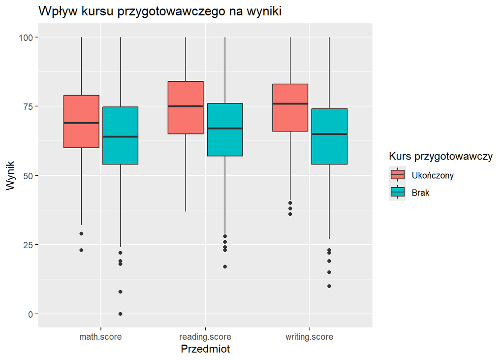

```r
ggplot(df_long, aes(x = subject, y = score, fill = test.preparation.course)) +
  geom_boxplot() +
  labs(title = "Wpływ kursu przygotowawczego na wyniki",
       x = "Przedmiot",
       y = "Wynik",
       fill = "Kurs przygotowawczy") +
  scale_x_discrete(labels = c("math" = "Matematyka", "reading" = "Czytanie", "writing" = "Pisanie")) +
  scale_fill_discrete(labels = c("completed" = "Ukończony", "none" = "Brak"))
```

**Komentarz:** Tak, uczniowie, którzy ukończyli kurs przygotowawczy, konsekwentnie osiągają lepsze wyniki ze wszystkich trzech przedmiotów. Ich mediany wyników są wyraźnie wyższe, a także cały zakres międzykwartylowy jest przesunięty w górę w porównaniu do uczniów, którzy nie odbyli kursu.

## Zadanie 4

Jaki jest związek między poziomem wykształcenia rodziców a średnimi wynikami uczniów?

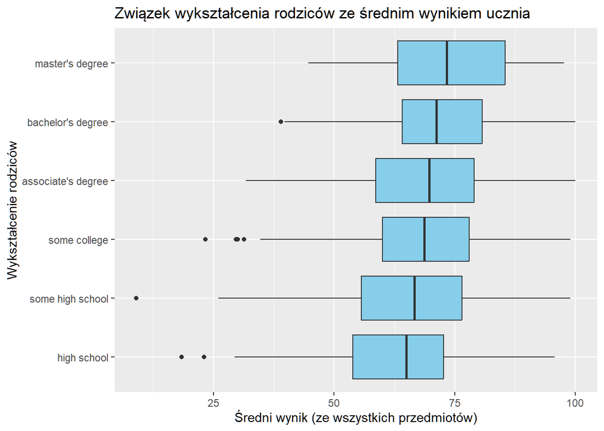

```r
df_avg <- df %>%
  mutate(average.score = (math.score + reading.score + writing.score) / 3)

ggplot(df_avg, aes(x = reorder(parental.level.of.education, average.score, FUN = median), y = average.score)) +
  geom_boxplot(fill = "skyblue") +
  labs(title = "Związek wykształcenia rodziców ze średnim wynikiem ucznia",
       x = "Wykształcenie rodziców",
       y = "Średni wynik (ze wszystkich przedmiotów)") +
  coord_flip()
```

## Zadanie 5

Czy płeć i wykształcenie rodzica wpływa na wynik z matematyki?

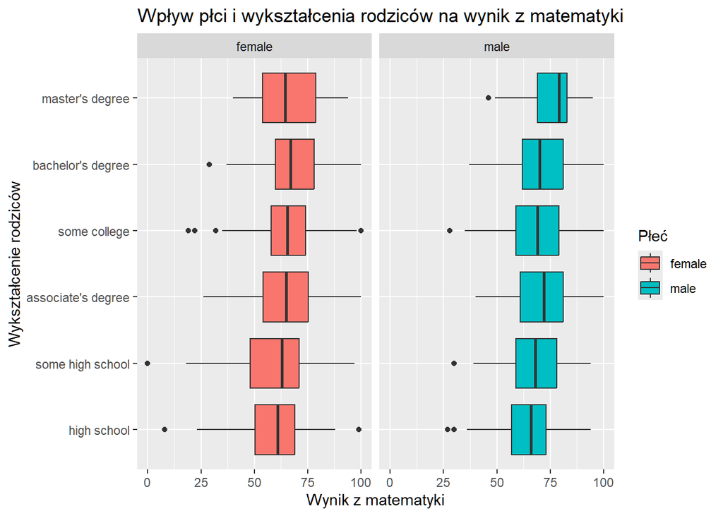

```r
ggplot(df, aes(x = reorder(parental.level.of.education, math.score, FUN = median), y = math.score, fill = gender)) +
  geom_boxplot() +
  facet_wrap(~ gender) +
  labs(title = "Wpływ płci i wykształcenia rodziców na wynik z matematyki",
       x = "Wykształcenie rodziców",
       y = "Wynik z matematyki",
       fill = "Płeć") +
  coord_flip()
```

**Komentarz:** Porównując oba panele, widać, że mężczyźni osiągają średnio wyższe wyniki z matematyki niż kobiety na każdym poziomie wykształcenia rodziców. Pudełka na wykresie dla mężczyzn są konsekwentnie przesunięte w górę w stosunku do pudełek dla kobiet. zależność między wykształceniem rodziców a wynikami jest generalnie pozytywna, ale nie jest idealnie liniowa i zawiera kilka anomalii takich jak niższa srednia dla master degree od associate’s degree dla kobiet.

## Zadanie 6

Czy istnieje zależność między wynikami z matematyki a wynikami z czytania lub pisania?

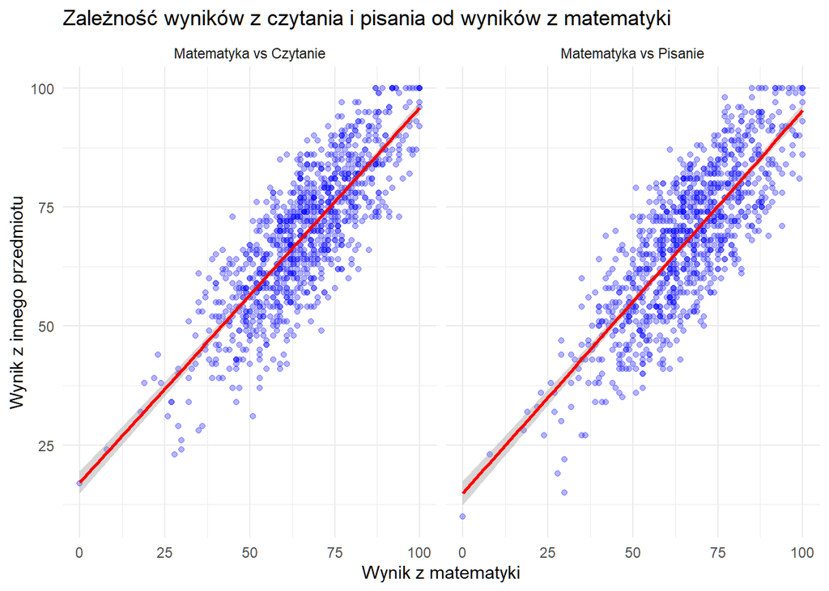

```r
df_cor_long <- df %>%
  pivot_longer(cols = c(reading.score, writing.score),
               names_to = "subject",
               values_to = "other_score")

df_cor_long$subject <- gsub(".score", "", df_cor_long$subject)

ggplot(df_cor_long, aes(x = math.score, y = other_score)) +
  geom_point(alpha = 0.3, color = "blue") +
  geom_smooth(method = "lm", color = "red") +
  facet_wrap(~ subject, labeller = as_labeller(c(reading = "Matematyka vs Czytanie", writing = "Matematyka vs Pisanie"))) +
  labs(title = "Zależność wyników z czytania i pisania od wyników z matematyki",
       x = "Wynik z matematyki",
       y = "Wynik z innego przedmiotu") +
  theme_minimal()
```

**Komentarz:** Tak, istnieje silna, pozytywna zależność liniowa między wynikami z matematyki a wynikami z pozostałych przedmiotów. Oznacza to, że uczniowie, którzy uzyskują wysokie wyniki z matematyki, mają również tendencję do uzyskiwania wysokich wyników z czytania i pisania (i odwrotnie). Chmury punktów na obu wykresach wyraźnie układają się wzdłuż rosnącej prostej, co potwierdzają dodane czerwone linie trendu (regresji).